# Pertemuan 1

Windi Gunawan

##Library yang digunakan

```r
library("forecast")
```

```r
library("graphics")
library("TTR")
library("TSA")
```

## Impor Data

```r
library("rio")
data <- import("https://raw.githubusercontent.com/Windi82/MPDWP1/main/Data/Data%20MPDW_Lama%20penyinaran%20Matahari%20Kota%20Bogor%202023.csv")
data <- data[,-4]
head(data)
```

```
##   No    Tanggal  ss
## 1  1 01/05/2023 6.1
## 2  2 02/05/2023 4.1
## 3  3 03/05/2023 7.5
## 4  4 04/05/2023 4.8
## 5  5 05/05/2023 5.5
## 6  6 06/05/2023 7.2
```

## Eksplorasi Data

Mengubah data agar terbaca sebagai data deret waktu dengan fungsi `ts()` .

```r
data.ts <- ts(data$ss)
```

Menampilkan ringkasan data

```r
summary(data.ts)
```

```
##    Min. 1st Qu.  Median    Mean 3rd Qu.    Max.
##   0.000   5.650   7.500   6.987   8.700  10.500
```

Membuat plot data deret waktu

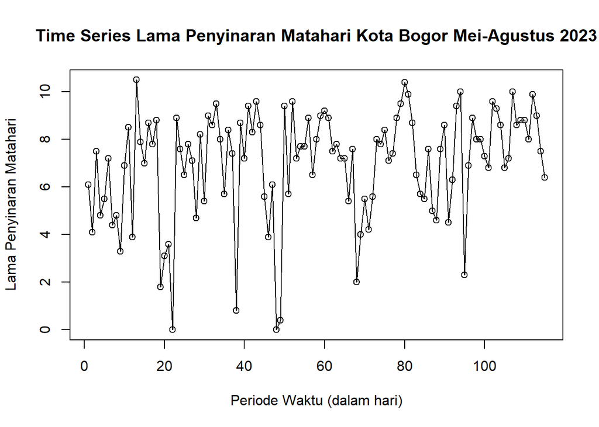

```r
ts.plot(data.ts, xlab="Periode Waktu (dalam hari)", ylab="Lama Penyinaran Matahari",
        main = "Time Series Lama Penyinaran Matahari Kota Bogor Mei-Agustus 2023")
points(data.ts)
```

## Single Moving Average & Double Moving Average

### Pembagian Data

Pembagian data latih dan data uji dilakukan dengan perbandingan 80% data latih dan 20% data uji.

```r
#membagi data latih dan data uji
datalatih <- data[1:92,]
datauji <- data[93:115,]
datalatih.ts <- ts(datalatih$ss)
datauji.ts <- ts(datauji$ss)
```

### Eksplorasi Data

Eksplorasi data dilakukan pada keseluruhan data, data latih serta data uji menggunakan plot data deret waktu.

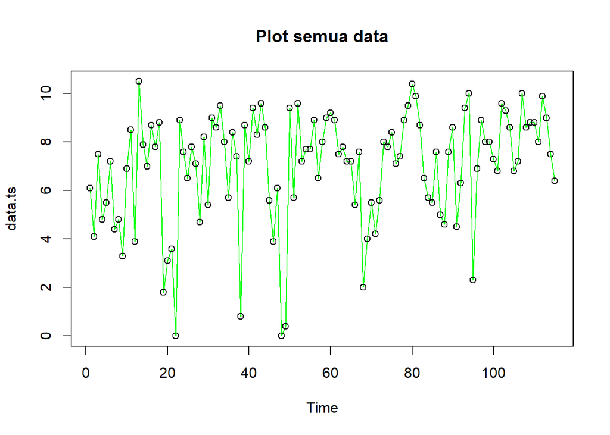

```r
#eksplorasi keseluruhan data
plot(data.ts, col="green",main="Plot semua data")
points(data.ts)
```

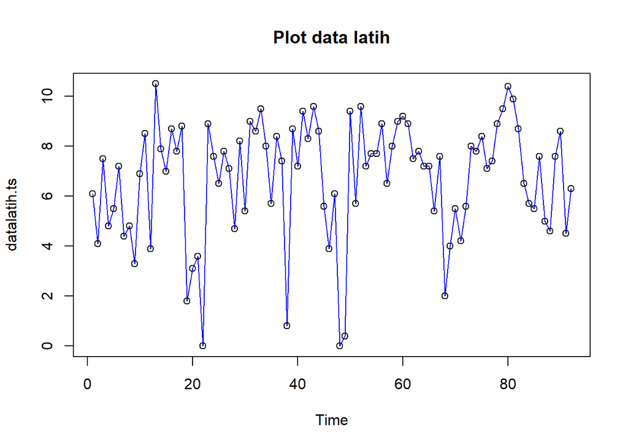

```r
#eksplorasi data latih
plot(datalatih.ts, col="blue",main="Plot data latih")
points(datalatih.ts)
```

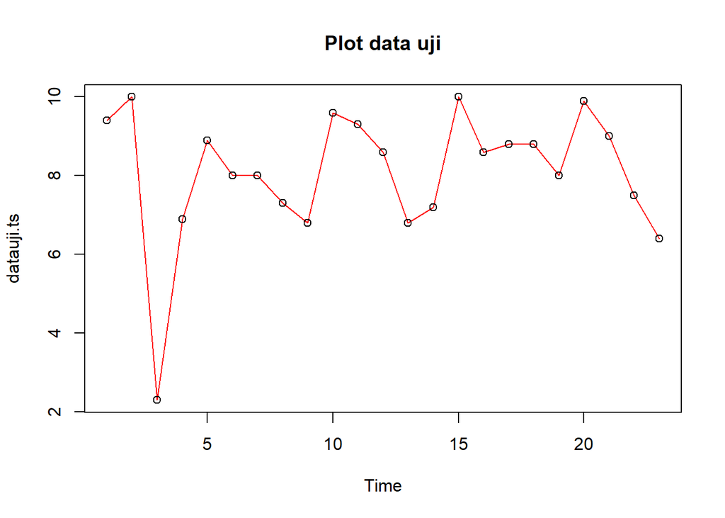

```r
#eksplorasi data uji
plot(datauji.ts, col="red",main="Plot data uji")
points(datauji.ts)
```

### Single Moving Average (SMA)

```r
data.sma<-SMA(datalatih.ts, m=4)
data.sma
```

```
## Time Series:
## Start = 1
## End = 92
## Frequency = 1
##  [1]   NA   NA   NA   NA   NA   NA   NA   NA   NA 5.46 5.70 5.68 5.98 6.29 6.44
## [16] 6.59 6.93 7.33 7.18 6.80 6.31 5.92 5.76 5.73 5.68 5.59 5.52 5.11 5.75 5.98
## [31] 6.52 7.38 7.44 7.48 7.40 7.46 7.49 7.10 7.15 7.33 7.37 7.34 7.35 7.41 7.40
## [46] 6.95 6.82 6.74 5.91 6.13 5.76 5.89 5.65 5.56 5.77 6.27 6.31 7.11 7.97 7.95
## [61] 8.27 8.06 8.12 8.07 8.02 7.67 7.78 7.18 6.68 6.31 5.84 5.65 5.67 5.73 5.85
## [76] 6.02 6.00 6.69 7.24 7.73 8.30 8.61 8.46 8.25 7.96 8.01 7.77 7.34 7.15 6.97
## [91] 6.43 6.19
```

Data pemulusan pada periode ke-t selanjutnya digunakan sebagai nilai peramalan pada periode ke t+1 sehingga hasil peramalan 1 periode kedepan adalah sebagai berikut.

```r
data.ramal<-c(NA,data.sma)
data.ramal #forecast 1 periode ke depan
```

```
##  [1]   NA   NA   NA   NA   NA   NA   NA   NA   NA   NA 5.46 5.70 5.68 5.98 6.29
## [16] 6.44 6.59 6.93 7.33 7.18 6.80 6.31 5.92 5.76 5.73 5.68 5.59 5.52 5.11 5.75
## [31] 5.98 6.52 7.38 7.44 7.48 7.40 7.46 7.49 7.10 7.15 7.33 7.37 7.34 7.35 7.41
## [46] 7.40 6.95 6.82 6.74 5.91 6.13 5.76 5.89 5.65 5.56 5.77 6.27 6.31 7.11 7.97
## [61] 7.95 8.27 8.06 8.12 8.07 8.02 7.67 7.78 7.18 6.68 6.31 5.84 5.65 5.67 5.73
## [76] 5.85 6.02 6.00 6.69 7.24 7.73 8.30 8.61 8.46 8.25 7.96 8.01 7.77 7.34 7.15
## [91] 6.97 6.43 6.19
```

Selanjutnya akan dilakukan peramalan sejumlah data uji yaitu 23 periode. Pada metode SMA, hasil peramalan 23 periode ke depan akan bernilai sama dengan hasil peramalan 1 periode kedepan. Dalam hal ini akan dilakukan pengguabungan data aktual train, data hasil pemulusan dan data hasil ramalan 23 periode kedepan.

```r
data.gab<-cbind(aktual=c(datalatih.ts,rep(NA,23)),pemulusan=c(data.sma,rep(NA,23)),ramalan=c(data.ramal,rep(data.ramal[length(data.ramal)],22)))
data.gab
```

```
##        aktual pemulusan ramalan
##   [1,]    6.1        NA      NA
##   [2,]    4.1        NA      NA
##   [3,]    7.5        NA      NA
##   [4,]    4.8        NA      NA
##   [5,]    5.5        NA      NA
##   [6,]    7.2        NA      NA
##   [7,]    4.4        NA      NA
##   [8,]    4.8        NA      NA
##   [9,]    3.3        NA      NA
##  [10,]    6.9      5.46      NA
##  [11,]    8.5      5.70    5.46
##  [12,]    3.9      5.68    5.70
##  [13,]   10.5      5.98    5.68
##  [14,]    7.9      6.29    5.98
```

[output cut: 101 more lines]

```r
head(data.gab, 15) #forecast 23 periode ke depan
```

```
##       aktual pemulusan ramalan
##  [1,]    6.1        NA      NA
##  [2,]    4.1        NA      NA
##  [3,]    7.5        NA      NA
##  [4,]    4.8        NA      NA
##  [5,]    5.5        NA      NA
##  [6,]    7.2        NA      NA
##  [7,]    4.4        NA      NA
##  [8,]    4.8        NA      NA
##  [9,]    3.3        NA      NA
## [10,]    6.9      5.46      NA
## [11,]    8.5      5.70    5.46
## [12,]    3.9      5.68    5.70
## [13,]   10.5      5.98    5.68
## [14,]    7.9      6.29    5.98
## [15,]    7.0      6.44    6.29
```

Adapun plot data deret waktu dari hasil peramalan yang dilakukan adalah sebagai berikut.

[figure not shown]

```r
ts.plot(data.ts, xlab="Periode Waktu", ylab="Lama Penyinaran Matahari", main= "SMA N=5 Data Lama Penyinaran Matahari")
points(data.ts)
lines(data.gab[,2],col="green",lwd=2)
lines(data.gab[,3],col="red",lwd=2)
legend("topleft",c("data aktual","data pemulusan","data peramalan"), lty=8, col=c("black","green","red"), cex=0.5)
```

Selanjutnya perhitungan akurasi dilakukan dengan ukuran akurasi *Sum Squares Error* (SSE), *Mean Square Error* (MSE) dan *Mean Absolute Percentage Error* (MAPE). Perhitungan akurasi dilakukan baik pada data latih maupun pada data uji.

```r
#Menghitung nilai keakuratan data latih
error_train.sma = datalatih.ts-data.ramal[1:length(datalatih.ts)]
SSE_train.sma = sum(error_train.sma[11:length(datalatih.ts)]^2)
MSE_train.sma = mean(error_train.sma[11:length(datalatih.ts)]^2)
MAPE_train.sma = mean(abs((error_train.sma[11:length(datalatih.ts)]/datalatih.ts[11:length(datalatih.ts)])*100))

akurasi_train.sma <- matrix(c(SSE_train.sma, MSE_train.sma, MAPE_train.sma))
row.names(akurasi_train.sma)<- c("SSE", "MSE", "MAPE")
colnames(akurasi_train.sma) <- c("Akurasi m = 4")
akurasi_train.sma
```

```
##      Akurasi m = 4
## SSE      575.58750
## MSE        7.01936
## MAPE           Inf
```

```r
#Menghitung nilai keakuratan data uji
error_test.sma = datauji.ts-data.gab[93:115,3]
SSE_test.sma = sum(error_test.sma^2)
MSE_test.sma = mean(error_test.sma^2)
MAPE_test.sma = mean(abs((error_test.sma/datauji.ts*100)))

akurasi_test.sma <- matrix(c(SSE_test.sma, MSE_test.sma, MAPE_test.sma))
row.names(akurasi_test.sma)<- c("SSE", "MSE", "MAPE")
colnames(akurasi_test.sma) <- c("Akurasi m = 5")
akurasi_test.sma
```

[output not shown]

### Double Moving Average (DMA)

Metode pemulusan Double Moving Average (DMA) pada dasarnya mirip dengan SMA. Namun demikian, metode ini lebih cocok digunakan untuk pola data trend. Proses pemulusan dengan rata rata dalam metode ini dilakukan sebanyak 2 kali.

```r
dma <- SMA(data.sma, n = 4)
At <- 2*data.sma - dma
Bt <- 2/(4-1)*(data.sma - dma)
data.dma<- At+Bt
data.ramal2<- c(NA, data.dma)

t = 1:25
f = c()

for (i in t) {
  f[i] = At[length(At)] + Bt[length(Bt)]*(i)
}

data.gab2 <- cbind(aktual = c(datalatih.ts,rep(NA,25)), pemulusan1 = c(data.sma,rep(NA,25)),pemulusan2 = c(data.dma, rep(NA,25)),At = c(At, rep(NA,25)), Bt = c(Bt,rep(NA,25)),ramalan = c(data.ramal2, f[-1]))
head(data.gab2,10)
```

```
##       aktual pemulusan1 pemulusan2 At Bt ramalan
##  [1,]    6.1         NA         NA NA NA      NA
##  [2,]    4.1         NA         NA NA NA      NA
##  [3,]    7.5         NA         NA NA NA      NA
##  [4,]    4.8         NA         NA NA NA      NA
##  [5,]    5.5         NA         NA NA NA      NA
##  [6,]    7.2         NA         NA NA NA      NA
##  [7,]    4.4         NA         NA NA NA      NA
##  [8,]    4.8         NA         NA NA NA      NA
##  [9,]    3.3         NA         NA NA NA      NA
## [10,]    6.9       5.46         NA NA NA      NA
```

Hasil pemulusan menggunakan metode DMA divisualisasikan sebagai berikut

[figure not shown]

```r
ts.plot(data.ts, xlab="Periode Waktu", ylab="Harga Beras", main= "DMA N=5 Data Harga Beras")
points(data.ts)
lines(data.gab2[,3],col="green",lwd=2)
lines(data.gab2[,6],col="red",lwd=2)
legend("topleft",c("data aktual","data pemulusan","data peramalan"), lty=8, col=c("black","green","red"), cex=0.8)
```

Selanjutnya perhitungan akurasi dilakukan baik pada data latih maupun data uji. Perhitungan akurasi dilakukan dengan ukuran akurasi SSE, MSE dan MAPE.

```r
#Menghitung nilai keakuratan data latih
error_train.dma = datalatih.ts-data.ramal2[1:length(datalatih.ts)]
SSE_train.dma = sum(error_train.dma[14:length(datalatih.ts)]^2)
MSE_train.dma = mean(error_train.dma[14:length(datalatih.ts)]^2)
MAPE_train.dma = mean(abs((error_train.dma[14:length(datalatih.ts)]/datalatih.ts[14:length(datalatih.ts)])*100))

akurasi_train.dma <- matrix(c(SSE_train.dma, MSE_train.dma, MAPE_train.dma))
row.names(akurasi_train.dma)<- c("SSE", "MSE", "MAPE")
colnames(akurasi_train.dma) <- c("Akurasi m = 5")
akurasi_train.dma
```

[output not shown]

```r
#Menghitung nilai keakuratan data uji
error_test.dma = datauji.ts-data.gab2[93:115,6]
SSE_test.dma = sum(error_test.dma^2)
MSE_test.dma = mean(error_test.dma^2)
MAPE_test.dma = mean(abs((error_test.dma/datauji.ts*100)))

akurasi_test.dma <- matrix(c(SSE_test.dma, MSE_test.dma, MAPE_test.dma))
row.names(akurasi_test.dma)<- c("SSE", "MSE", "MAPE")
colnames(akurasi_test.dma) <- c("Akurasi m = 4")
akurasi_test.dma
```

```
##      Akurasi m = 4
## SSE     1125.38298
## MSE       48.92969
## MAPE      81.94624
```

## Single Exponential Smoothing & Double Exponential Smoothing

Metode *Exponential Smoothing* adalah metode pemulusan dengan melakukan pembobotan menurun secara eksponensial. Nilai yang lebih baru diberi bobot yang lebih besar dari nilai terdahulu. Terdapat satu atau lebih parameter pemulusan yang ditentukan secara eksplisit, dan hasil pemilihan parameter tersebut akan menentukan bobot yang akan diberikan pada nilai pengamatan. Ada dua macam model, yaitu model tunggal dan ganda.

### Pembagian Data

Pembagian data latih dan data uji dilakukan dengan perbandingan 80% data latih dan 20% data uji.

```r
#membagi training dan testing
Periode1 <- c(1:92)
Periode2 <- c(93:115)
training <- cbind(data[1:92,],Periode1)
testing <- cbind(data[93:115,],Periode2)
train.ts <- ts(training$ss)
test.ts <- ts(testing$ss)
```

#Eksplorasi data dapat dilakukan menggunakan package `ggplot2` .

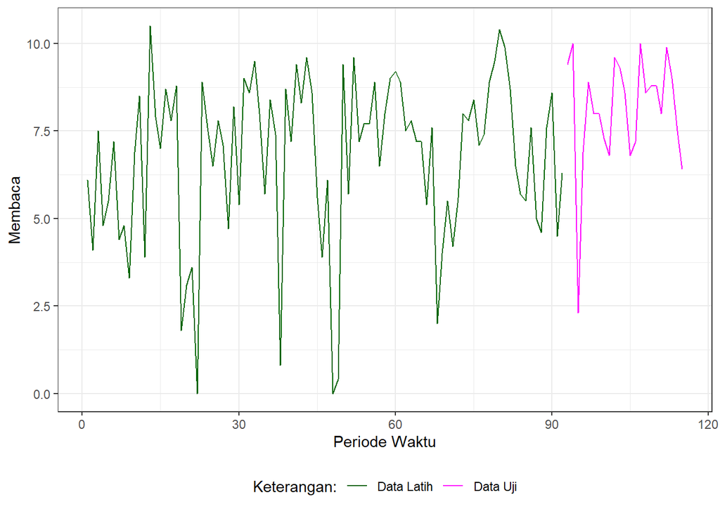

```r
#Eksplorasi dengan GGPLOT
library(ggplot2)
ggplot() +
  geom_line(data = training, aes(x = Periode1, y = ss, col = "Data Latih")) +
  geom_line(data = testing, aes(x = Periode2, y = ss, col = "Data Uji")) +
  labs(x = "Periode Waktu", y = "Membaca", color = "Legend") +
  scale_colour_manual(name="Keterangan:", breaks = c("Data Latih", "Data Uji"),
                      values = c("darkgreen", "magenta")) +
  theme_bw() + theme(legend.position = "bottom",
                     plot.caption = element_text(hjust=0.5, size=12))
```

### SES

Single Exponential Smoothing merupakan metode pemulusan yang tepat digunakan untuk data dengan pola stasioner atau konstan. Nilai pemulusan pada periode ke-t didapat dari persamaan:
$$\tilde{y}_T=\lambda y_t+(1-\lambda)\tilde{y}_{T-1}$$

Nilai parameter $\lambda$ adalah nilai antara 0 dan 1. Nilai pemulusan periode ke-t bertindak sebagai nilai ramalan pada periode ke-$(T+\tau)$.
$$\tilde{y}_{T+\tau}(T)=\tilde{y}_T$$

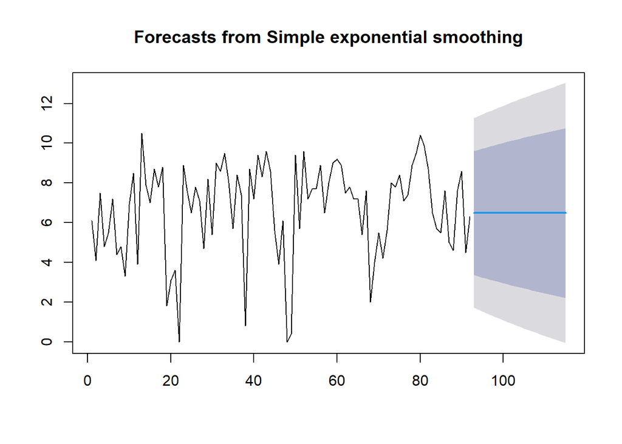

```r
#Cara 1 (fungsi ses)
ses.1 <- ses(train.ts, h = 23, alpha = 0.2)
plot(ses.1)
```

```r
ses.1
```

```
##     Point Forecast    Lo 80     Hi 80       Lo 95    Hi 95
##  93       6.485064 3.364571  9.605557  1.71268152 11.25745
##  94       6.485064 3.302773  9.667355  1.61816973 11.35196
##  95       6.485064 3.242152  9.727975  1.52545865 11.44467
##  96       6.485064 3.182644  9.787483  1.43444913 11.53568
##  97       6.485064 3.124190  9.845938  1.34505078 11.62508
##  98       6.485064 3.066735  9.903393  1.25718094 11.71295
##  99       6.485064 3.010230  9.959898  1.17076380 11.79936
## 100       6.485064 2.954629 10.015499  1.08572959 11.88440
## 101       6.485064 2.899890 10.070238  1.00201399 11.96811
## 102       6.485064 2.845975 10.124153  0.91955749 12.05057
## 103       6.485064 2.792847 10.177281  0.83830492 12.13182
## 104       6.485064 2.740472 10.229656  0.75820505 12.21192
## 105       6.485064 2.688820 10.281308  0.67921016 12.29092
## 106       6.485064 2.637862 10.332266  0.60127575 12.36885
## 107       6.485064 2.587569 10.382559  0.52436022 12.44577
## 108       6.485064 2.537918 10.432210  0.44842463 12.52170
## 109       6.485064 2.488883 10.481245  0.37343245 12.59670
## 110       6.485064 2.440443 10.529685  0.29934936 12.67078
## 111       6.485064 2.392576 10.577552  0.22614309 12.74398
## 112       6.485064 2.345262 10.624866  0.15378322 12.81634
## 113       6.485064 2.298483 10.671645  0.08224106 12.88789
## 114       6.485064 2.252221 10.717907  0.01148948 12.95864
## 115       6.485064 2.206459 10.763668 -0.05849714 13.02862
```

```r
ramalan1<- forecast(ses.1, h=23)
ramalan1
```

```
##     Point Forecast    Lo 80     Hi 80       Lo 95    Hi 95
##  93       6.485064 3.364571  9.605557  1.71268152 11.25745
##  94       6.485064 3.302773  9.667355  1.61816973 11.35196
##  95       6.485064 3.242152  9.727975  1.52545865 11.44467
##  96       6.485064 3.182644  9.787483  1.43444913 11.53568
##  97       6.485064 3.124190  9.845938  1.34505078 11.62508
##  98       6.485064 3.066735  9.903393  1.25718094 11.71295
##  99       6.485064 3.010230  9.959898  1.17076380 11.79936
## 100       6.485064 2.954629 10.015499  1.08572959 11.88440
## 101       6.485064 2.899890 10.070238  1.00201399 11.96811
## 102       6.485064 2.845975 10.124153  0.91955749 12.05057
## 103       6.485064 2.792847 10.177281  0.83830492 12.13182
## 104       6.485064 2.740472 10.229656  0.75820505 12.21192
## 105       6.485064 2.688820 10.281308  0.67921016 12.29092
## 106       6.485064 2.637862 10.332266  0.60127575 12.36885
## 107       6.485064 2.587569 10.382559  0.52436022 12.44577
## 108       6.485064 2.537918 10.432210  0.44842463 12.52170
## 109       6.485064 2.488883 10.481245  0.37343245 12.59670
## 110       6.485064 2.440443 10.529685  0.29934936 12.67078
## 111       6.485064 2.392576 10.577552  0.22614309 12.74398
## 112       6.485064 2.345262 10.624866  0.15378322 12.81634
## 113       6.485064 2.298483 10.671645  0.08224106 12.88789
## 114       6.485064 2.252221 10.717907  0.01148948 12.95864
## 115       6.485064 2.206459 10.763668 -0.05849714 13.02862
```

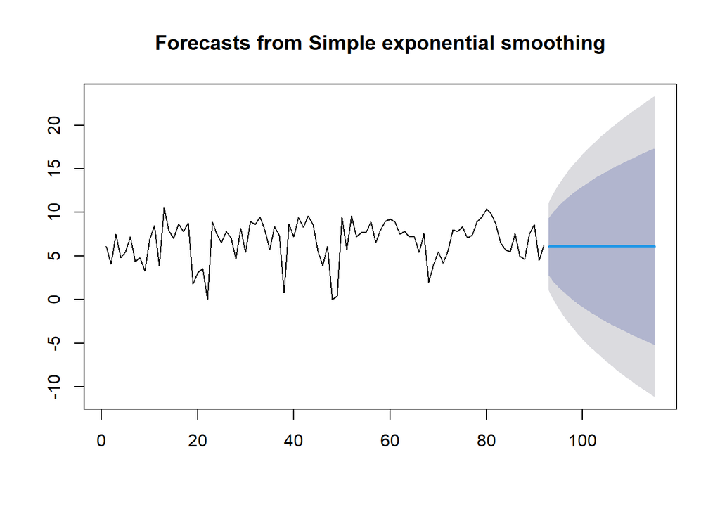

```r
ses.2<- ses(train.ts, h = 23, alpha = 0.7)
plot(ses.2)
```

```r
ses.2
```

```
##     Point Forecast       Lo 80     Hi 80        Lo 95    Hi 95
##  93       6.080152  2.79496135  9.365343   1.05588637 11.10442
##  94       6.080152  2.07006572 10.090239  -0.05274582 12.21305
##  95       6.080152  1.45747893 10.702825  -0.98961648 13.14992
##  96       6.080152  0.91706952 11.243235  -1.81610135 13.97641
##  97       6.080152  0.42809616 11.732208  -2.56392156 14.72423
##  98       6.080152 -0.02181896 12.182123  -3.25200737 15.41231
##  99       6.080152 -0.44076543 12.601070  -3.89273070 16.05304
## 100       6.080152 -0.83437463 12.994679  -4.49470403 16.65501
## 101       6.080152 -1.20675359 13.367058  -5.06420849 17.22451
## 102       6.080152 -1.56100678 13.721311  -5.60599200 17.76630
## 103       6.080152 -1.89954862 14.059853  -6.12374707 18.28405
## 104       6.080152 -2.22430081 14.384605  -6.62041268 18.78072
## 105       6.080152 -2.53682259 14.697127  -7.09837349 19.25868
## 106       6.080152 -2.83839976 14.998704  -7.55959598 19.71990
## 107       6.080152 -3.13010750 15.290412  -8.00572446 20.16603
## 108       6.080152 -3.41285567 15.573160  -8.43815047 20.59845
## 109       6.080152 -3.68742237 15.847727  -8.85806401 21.01837
## 110       6.080152 -3.95447921 16.114784  -9.26649220 21.42680
## 111       6.080152 -4.21461066 16.374915  -9.66432891 21.82463
## 112       6.080152 -4.46832906 16.628633 -10.05235773 22.21266
## 113       6.080152 -4.71608657 16.876391 -10.43127013 22.59157
## 114       6.080152 -4.95828456 17.118589 -10.80168000 22.96198
## 115       6.080152 -5.19528131 17.355586 -11.16413525 23.32444
```

```r
ramalan2<- forecast(ses.2, h=23)
ramalan2
```

```
##     Point Forecast       Lo 80     Hi 80        Lo 95    Hi 95
##  93       6.080152  2.79496135  9.365343   1.05588637 11.10442
##  94       6.080152  2.07006572 10.090239  -0.05274582 12.21305
##  95       6.080152  1.45747893 10.702825  -0.98961648 13.14992
##  96       6.080152  0.91706952 11.243235  -1.81610135 13.97641
##  97       6.080152  0.42809616 11.732208  -2.56392156 14.72423
##  98       6.080152 -0.02181896 12.182123  -3.25200737 15.41231
##  99       6.080152 -0.44076543 12.601070  -3.89273070 16.05304
## 100       6.080152 -0.83437463 12.994679  -4.49470403 16.65501
## 101       6.080152 -1.20675359 13.367058  -5.06420849 17.22451
## 102       6.080152 -1.56100678 13.721311  -5.60599200 17.76630
## 103       6.080152 -1.89954862 14.059853  -6.12374707 18.28405
## 104       6.080152 -2.22430081 14.384605  -6.62041268 18.78072
## 105       6.080152 -2.53682259 14.697127  -7.09837349 19.25868
## 106       6.080152 -2.83839976 14.998704  -7.55959598 19.71990
## 107       6.080152 -3.13010750 15.290412  -8.00572446 20.16603
## 108       6.080152 -3.41285567 15.573160  -8.43815047 20.59845
## 109       6.080152 -3.68742237 15.847727  -8.85806401 21.01837
## 110       6.080152 -3.95447921 16.114784  -9.26649220 21.42680
## 111       6.080152 -4.21461066 16.374915  -9.66432891 21.82463
## 112       6.080152 -4.46832906 16.628633 -10.05235773 22.21266
## 113       6.080152 -4.71608657 16.876391 -10.43127013 22.59157
## 114       6.080152 -4.95828456 17.118589 -10.80168000 22.96198
## 115       6.080152 -5.19528131 17.355586 -11.16413525 23.32444
```

Untuk mendapatkan gambar hasil pemulusan pada data latih dengan fungsi `ses()` , perlu digunakan fungsi `autoplot()` dan `autolayer()` dari *library packages* `ggplot2` .

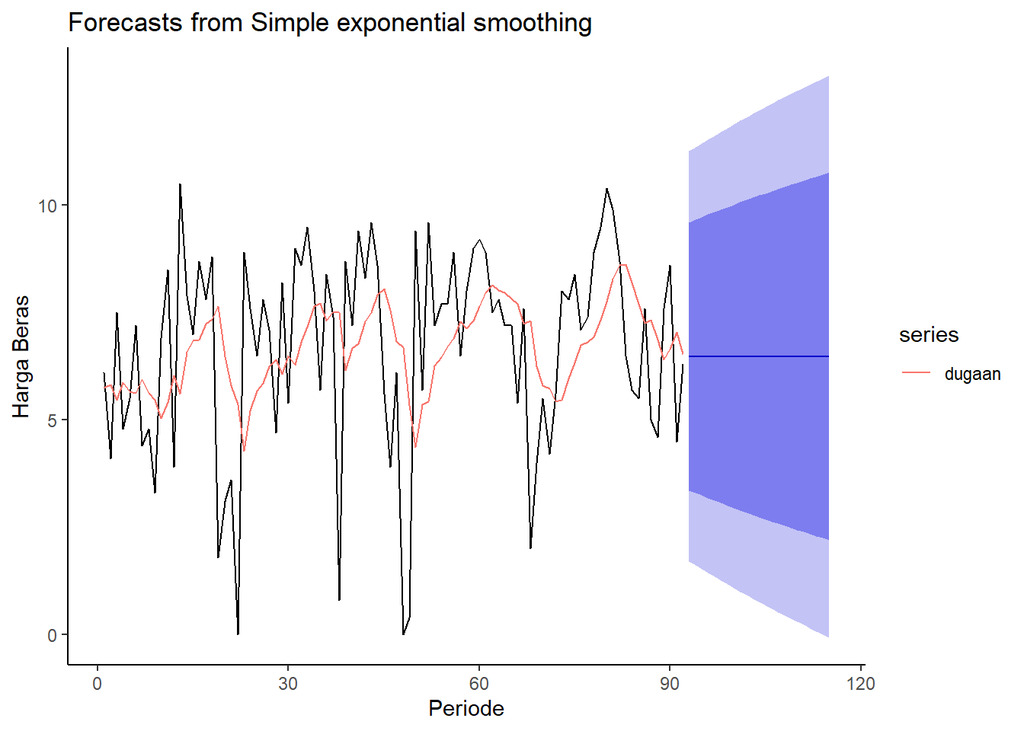

```r
autoplot(ses.1) +
  autolayer(fitted(ses.1), series="dugaan") +
  ylab("Harga Beras") + xlab("Periode") + theme_classic()
```

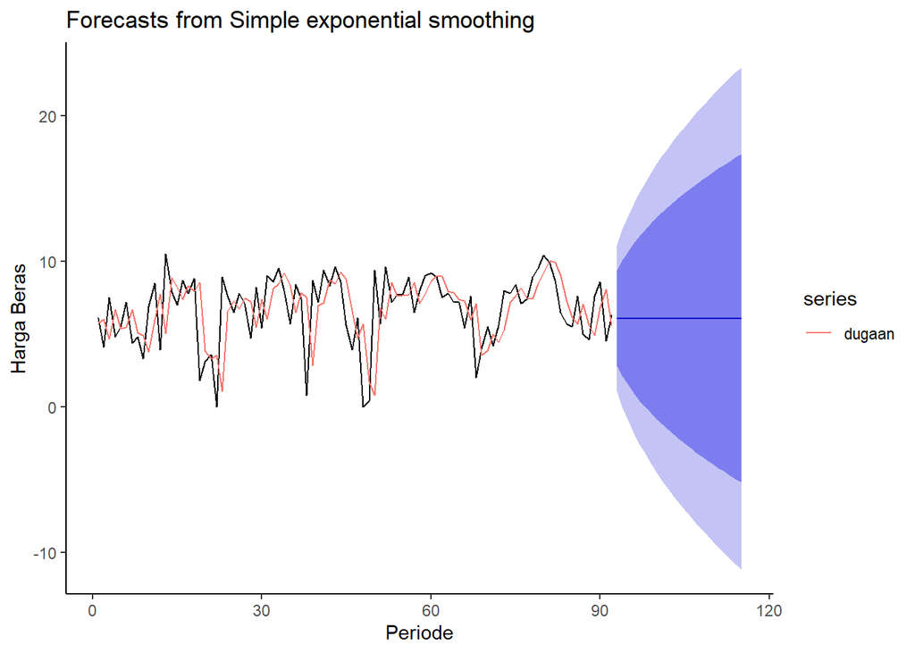

```r
autoplot(ses.2) +
  autolayer(fitted(ses.2), series="dugaan") +
  ylab("Harga Beras") + xlab("Periode") + theme_classic()
```

Pada fungsi `ses()` , terdapat beberapa argumen yang umum digunakan, yaitu nilia `y` , `gamma` , `beta` , `alpha` , dan `h` .

Nilai `y` adalah nilai data deret waktu, `gamma` adalah parameter pemulusan untuk komponen musiman, `beta` adalah parameter pemulusan untuk tren, dan `alpha` adalah parameter pemulusan untuk stasioner, serta `h` adalah banyaknya periode yang akan diramalkan.

Fungsi `HoltWinters` memiliki argumen yang sama dengan fungsi `ses()` . Argumen-argumen kedua fungsi dapat dilihat lebih lanjut dengan `?ses()` atau `?HoltWinters` .

Nilai parameter $\alpha$ dari kedua fungsi dapat dioptimalkan menyesuaikan dari *error*-nya paling minimumnya. Caranya adalah dengan membuat parameter $\alpha =$ `NULL` .

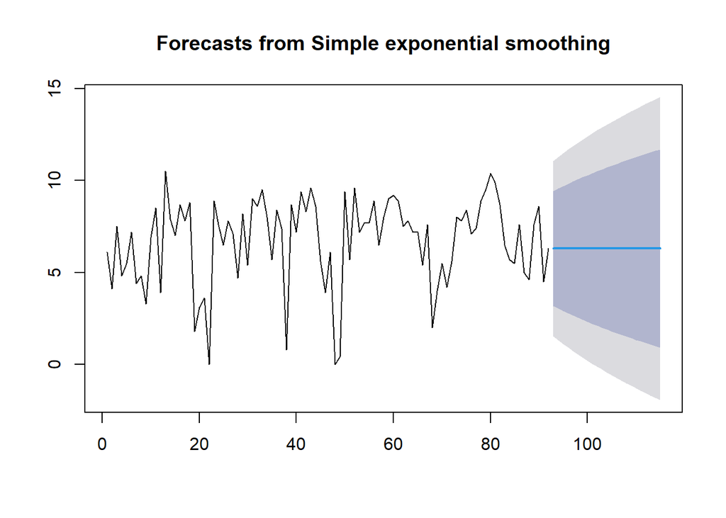

```r
#SES
ses.opt <- ses(train.ts, h = 23, alpha = NULL)
plot(ses.opt)
```

```r
ses.opt
```

```
##     Point Forecast     Lo 80     Hi 80       Lo 95    Hi 95
##  93       6.300787 3.1829198  9.418654  1.53242061 11.06915
##  94       6.300787 3.0450756  9.556499  1.32160605 11.27997
##  95       6.300787 2.9128352  9.688739  1.11936174 11.48221
##  96       6.300787 2.7855660  9.816008  0.92472036 11.67685
##  97       6.300787 2.6627464  9.938828  0.73688393 11.86469
##  98       6.300787 2.5439398 10.057634  0.55518501 12.04639
##  99       6.300787 2.4287770 10.172797  0.37905862 12.22252
## 100       6.300787 2.3169418 10.284632  0.20802146 12.39355
## 101       6.300787 2.2081615 10.393413  0.04165633 12.55992
## 102       6.300787 2.1021986 10.499376 -0.12039993 12.72197
## 103       6.300787 1.9988449 10.602729 -0.27846572 12.88004
## 104       6.300787 1.8979167 10.703657 -0.43282208 13.03440
## 105       6.300787 1.7992508 10.802323 -0.58371851 13.18529
## 106       6.300787 1.7027017 10.898873 -0.73137774 13.33295
## 107       6.300787 1.6081385 10.993436 -0.87599959 13.47757
## 108       6.300787 1.5154437 11.086130 -1.01776412 13.61934
## 109       6.300787 1.4245106 11.177064 -1.15683430 13.75841
## 110       6.300787 1.3352424 11.266332 -1.29335813 13.89493
## 111       6.300787 1.2475510 11.354023 -1.42747057 14.02904
## 112       6.300787 1.1613556 11.440219 -1.55929506 14.16087
## 113       6.300787 1.0765822 11.524992 -1.68894483 14.29052
## 114       6.300787 0.9931626 11.608412 -1.81652411 14.41810
## 115       6.300787 0.9110339 11.690540 -1.94212902 14.54370
```

```r
#ramalan
ramalanopt<- forecast(ses.opt, h=23)
ramalanopt
```

```
##     Point Forecast     Lo 80     Hi 80       Lo 95    Hi 95
##  93       6.300787 3.1829198  9.418654  1.53242061 11.06915
##  94       6.300787 3.0450756  9.556499  1.32160605 11.27997
##  95       6.300787 2.9128352  9.688739  1.11936174 11.48221
##  96       6.300787 2.7855660  9.816008  0.92472036 11.67685
##  97       6.300787 2.6627464  9.938828  0.73688393 11.86469
##  98       6.300787 2.5439398 10.057634  0.55518501 12.04639
##  99       6.300787 2.4287770 10.172797  0.37905862 12.22252
## 100       6.300787 2.3169418 10.284632  0.20802146 12.39355
## 101       6.300787 2.2081615 10.393413  0.04165633 12.55992
## 102       6.300787 2.1021986 10.499376 -0.12039993 12.72197
## 103       6.300787 1.9988449 10.602729 -0.27846572 12.88004
## 104       6.300787 1.8979167 10.703657 -0.43282208 13.03440
## 105       6.300787 1.7992508 10.802323 -0.58371851 13.18529
## 106       6.300787 1.7027017 10.898873 -0.73137774 13.33295
## 107       6.300787 1.6081385 10.993436 -0.87599959 13.47757
## 108       6.300787 1.5154437 11.086130 -1.01776412 13.61934
## 109       6.300787 1.4245106 11.177064 -1.15683430 13.75841
## 110       6.300787 1.3352424 11.266332 -1.29335813 13.89493
## 111       6.300787 1.2475510 11.354023 -1.42747057 14.02904
## 112       6.300787 1.1613556 11.440219 -1.55929506 14.16087
## 113       6.300787 1.0765822 11.524992 -1.68894483 14.29052
## 114       6.300787 0.9931626 11.608412 -1.81652411 14.41810
## 115       6.300787 0.9110339 11.690540 -1.94212902 14.54370
```

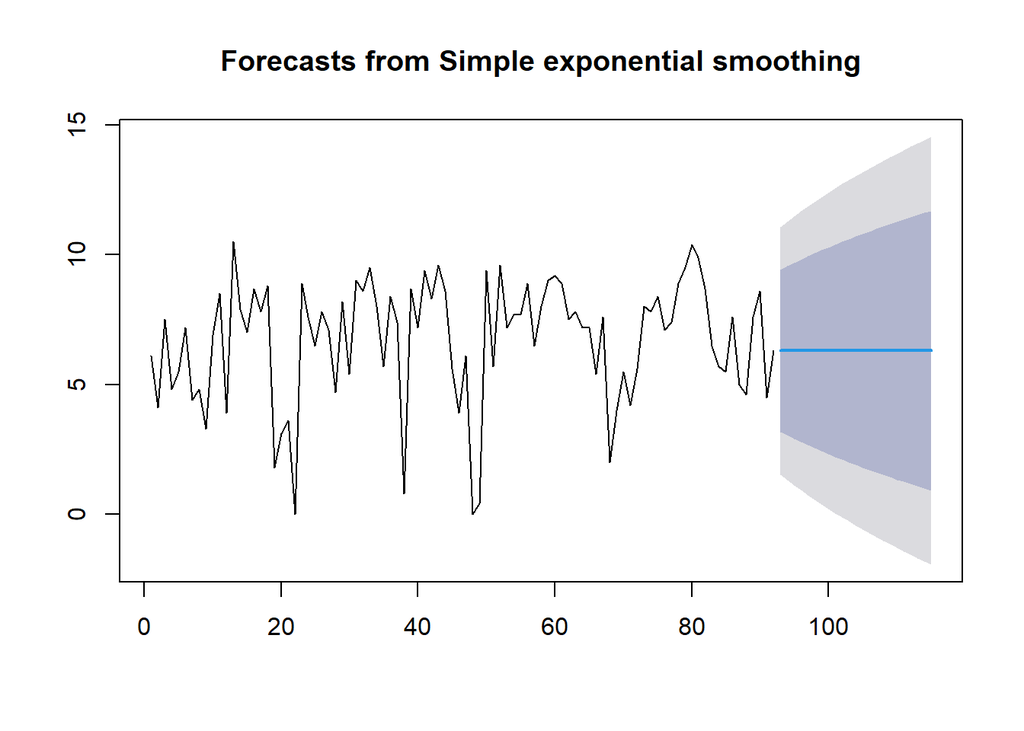

```r
#SES
ses.opt <- ses(train.ts, h = 23, alpha = NULL)
plot(ses.opt)
```

```r
ses.opt
```

```
##     Point Forecast     Lo 80     Hi 80       Lo 95    Hi 95
##  93       6.300787 3.1829198  9.418654  1.53242061 11.06915
##  94       6.300787 3.0450756  9.556499  1.32160605 11.27997
##  95       6.300787 2.9128352  9.688739  1.11936174 11.48221
##  96       6.300787 2.7855660  9.816008  0.92472036 11.67685
##  97       6.300787 2.6627464  9.938828  0.73688393 11.86469
##  98       6.300787 2.5439398 10.057634  0.55518501 12.04639
##  99       6.300787 2.4287770 10.172797  0.37905862 12.22252
## 100       6.300787 2.3169418 10.284632  0.20802146 12.39355
## 101       6.300787 2.2081615 10.393413  0.04165633 12.55992
## 102       6.300787 2.1021986 10.499376 -0.12039993 12.72197
## 103       6.300787 1.9988449 10.602729 -0.27846572 12.88004
## 104       6.300787 1.8979167 10.703657 -0.43282208 13.03440
## 105       6.300787 1.7992508 10.802323 -0.58371851 13.18529
## 106       6.300787 1.7027017 10.898873 -0.73137774 13.33295
## 107       6.300787 1.6081385 10.993436 -0.87599959 13.47757
## 108       6.300787 1.5154437 11.086130 -1.01776412 13.61934
## 109       6.300787 1.4245106 11.177064 -1.15683430 13.75841
## 110       6.300787 1.3352424 11.266332 -1.29335813 13.89493
## 111       6.300787 1.2475510 11.354023 -1.42747057 14.02904
## 112       6.300787 1.1613556 11.440219 -1.55929506 14.16087
## 113       6.300787 1.0765822 11.524992 -1.68894483 14.29052
## 114       6.300787 0.9931626 11.608412 -1.81652411 14.41810
## 115       6.300787 0.9110339 11.690540 -1.94212902 14.54370
```

```r
#Lamda Optimum Holt Winter
sesopt<- HoltWinters(train.ts, gamma = FALSE, beta = FALSE,alpha = NULL)
sesopt
```

```
## Holt-Winters exponential smoothing without trend and without seasonal component.
##
## Call:
## HoltWinters(x = train.ts, alpha = NULL, beta = FALSE, gamma = FALSE)
##
## Smoothing parameters:
##  alpha: 0.3017066
##  beta : FALSE
##  gamma: FALSE
##
## Coefficients:
##       [,1]
## a 6.299477
```

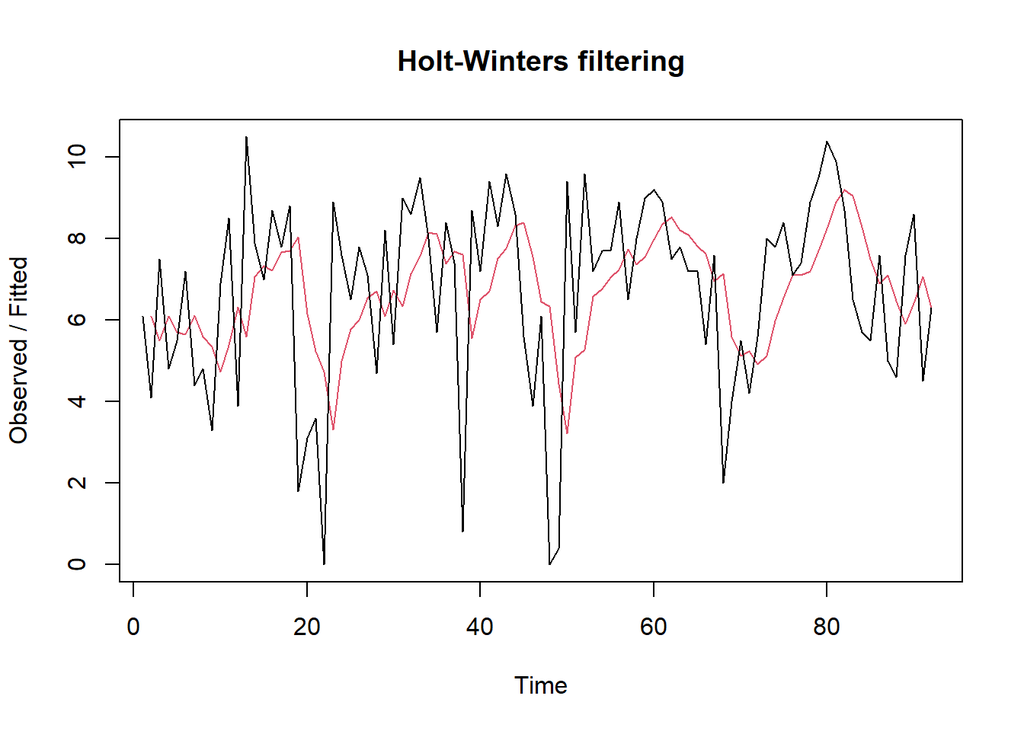

```r
plot(sesopt)
```

```r
#ramalan
ramalanopt<- forecast(sesopt, h=23)
ramalanopt
```

```
##     Point Forecast     Lo 80     Hi 80       Lo 95    Hi 95
##  93       6.299477 3.1805606  9.418394  1.52950595 11.06945
##  94       6.299477 3.0416993  9.557255  1.31713585 11.28182
##  95       6.299477 2.9085196  9.690435  1.11345512 11.48550
##  96       6.299477 2.7803765  9.818578  0.91747713 11.68148
##  97       6.299477 2.6567384  9.942216  0.72838894 11.87057
##  98       6.299477 2.5371611 10.061793  0.54551126 12.05344
##  99       6.299477 2.4212690 10.177685  0.36826959 12.23068
## 100       6.299477 2.3087410 10.290213  0.19617289 12.40278
## 101       6.299477 2.1993001 10.399654  0.02879756 12.57016
## 102       6.299477 2.0927055 10.506249 -0.13422491 12.73318
## 103       6.299477 1.9887459 10.610208 -0.29321743 12.89217
## 104       6.299477 1.8872350 10.711719 -0.44846487 13.04742
## 105       6.299477 1.7880076 10.810947 -0.60022003 13.19917
## 106       6.299477 1.6909163 10.908038 -0.74870849 13.34766
## 107       6.299477 1.5958286 11.003126 -0.89413254 13.49309
## 108       6.299477 1.5026254 11.096329 -1.03667444 13.63563
## 109       6.299477 1.4111991 11.187755 -1.17649902 13.77545
## 110       6.299477 1.3214515 11.277503 -1.31375603 13.91271
## 111       6.299477 1.2332936 11.365661 -1.44858190 14.04754
## 112       6.299477 1.1466438 11.452310 -1.58110143 14.18006
## 113       6.299477 1.0614271 11.537527 -1.71142906 14.31038
## 114       6.299477 0.9775748 11.621379 -1.83967010 14.43862
## 115       6.299477 0.8950233 11.703931 -1.96592167 14.56488
```

Setelah dilakukan peramalan, akan dilakukan perhitungan keakuratan hasil peramalan. Perhitungan akurasi ini dilakukan baik pada data latih dan data uji.

```r
#Keakuratan Metode
accuracy(ramalan1,testing$ss)
```

```
##                      ME     RMSE      MAE      MPE     MAPE      MASE      ACF1
## Training set 0.04029347 2.408322 1.898883     -Inf      Inf 0.8981202 0.1554395
## Test set     1.60624045 2.296486 1.977556 12.12246 28.06059 0.9353305        NA
```

```r
accuracy(ramalan2,testing$ss)
```

```
##                       ME     RMSE      MAE      MPE     MAPE      MASE
## Training set 0.005258089 2.535431 1.843730     -Inf      Inf 0.8720345
## Test set     2.011152161 2.595876 2.339861 17.60933 31.90102 1.1066910
##                    ACF1
## Training set -0.2749743
## Test set             NA
```

```r
accuracy(ramalanopt,testing$ss)
```

```
##                       ME     RMSE      MAE      MPE    MAPE      MASE
## Training set 0.007265524 2.420305 1.877258     -Inf     Inf 0.8878924
## Test set     1.791827238 2.429914 2.139608 14.63731 29.7582 1.0119767
##                    ACF1
## Training set 0.06841215
## Test set             NA
```

### DES

Metode pemulusan *Double Exponential Smoothing* (DES) digunakan untuk data yang memiliki pola tren. Metode DES adalah metode semacam SES, hanya saja dilakukan dua kali, yaitu pertama untuk tahapan ‘level’ dan kedua untuk tahapan ‘tren’. Pemulusan menggunakan metode ini akan menghasilkan peramalan tidak konstan untuk periode berikutnya.

Pemulusan dengan metode DES kali ini akan menggunakan fungsi `HoltWinters()` . Jika sebelumnya nilai argumen `beta` dibuat `FALSE` , kali ini argumen tersebut akan diinisialisasi bersamaan dengan nilai `alpha` .

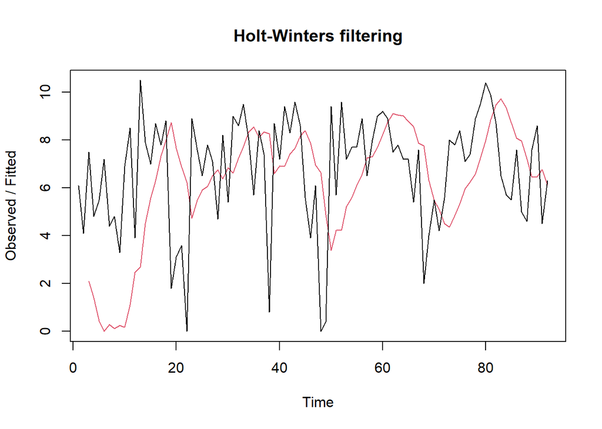

```r
#Lamda=0.2 dan gamma=0.2
des.1<- HoltWinters(train.ts, gamma = FALSE, beta = 0.2, alpha = 0.2)
plot(des.1)
```

```r
#ramalan
ramalandes1<- forecast(des.1, h=25)
ramalandes1
```

```
##     Point Forecast       Lo 80     Hi 80       Lo 95    Hi 95
##  93       5.944369   1.8196987 10.069040  -0.3637699 12.25251
##  94       5.741005   1.4992071  9.982803  -0.7462650 12.22828
##  95       5.537641   1.1414310  9.933851  -1.1857819 12.26106
##  96       5.334277   0.7442024  9.924351  -1.6856362 12.35419
##  97       5.130913   0.3066349  9.955190  -2.2471834 12.50901
##  98       4.927548  -0.1710514 10.026148  -2.8700871 12.72518
##  99       4.724184  -0.6877856 10.136154  -3.5527095 13.00108
## 100       4.520820  -1.2419215 10.283562  -4.2925327 13.33417
## 101       4.317456  -1.8314855 10.466398  -5.0865385 13.72145
## 102       4.114092  -2.4543728 10.682557  -5.9315080 14.15969
## 103       3.910728  -3.1084869 10.929943  -6.8242348 14.64569
## 104       3.707364  -3.7918271 11.206554  -7.7616589 15.17639
## 105       3.504000  -4.5025371 11.510536  -8.7409416 15.74894
## 106       3.300635  -5.2389266 11.840197  -9.7594977 16.36077
## 107       3.097271  -5.9994740 12.194017 -10.8150001 17.00954
## 108       2.893907  -6.7828193 12.570634 -11.9053688 17.69318
## 109       2.690543  -7.5877516 12.968838 -13.0287521 18.40984
## 110       2.487179  -8.4131943 13.387552 -14.1835033 19.15786
## 111       2.283815  -9.2581894 13.825819 -15.3681573 19.93579
## 112       2.080451 -10.1218833 14.282785 -16.5814087 20.74231
## 113       1.877086 -11.0035136 14.757687 -17.8220914 21.57626
## 114       1.673722 -11.9023970 15.249842 -19.0891605 22.43661
## 115       1.470358 -12.8179192 15.758636 -20.3816764 23.32239
## 116       1.266994 -13.7495255 16.283514 -21.6987908 24.23278
## 117       1.063630 -14.6967135 16.823973 -23.0397354 25.16700
```

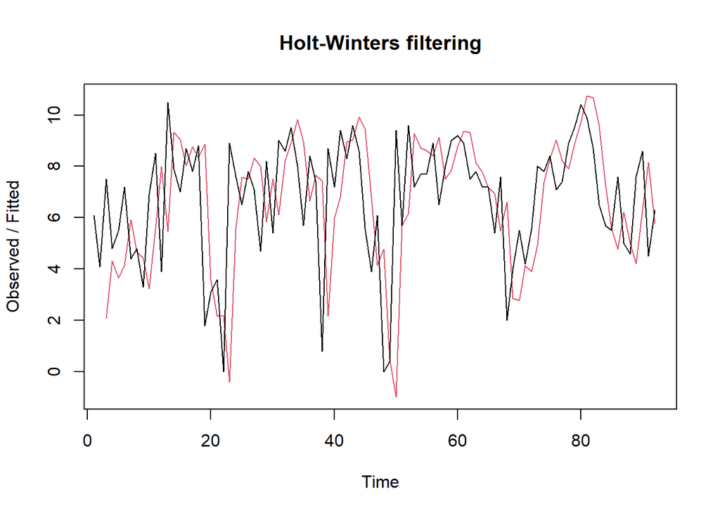

```r
#Lamda=0.6 dan gamma=0.3
des.2<- HoltWinters(train.ts, gamma = FALSE, beta = 0.3, alpha = 0.6)
plot(des.2)
```

```r
#ramalan
ramalandes2<- forecast(des.2, h=25)
ramalandes2
```

```
##     Point Forecast        Lo 80     Hi 80      Lo 95    Hi 95
##  93       6.001509   2.38068728  9.622331   0.463940 11.53908
##  94       5.911177   1.31915248 10.503201  -1.111718 12.93407
##  95       5.820845   0.06157496 11.580115  -2.987198 14.62889
##  96       5.730513  -1.35520556 12.816231  -5.106158 16.56718
##  97       5.640180  -2.90680024 14.187161  -7.431298 18.71166
##  98       5.549848  -4.57680815 15.676504  -9.937536 21.03723
##  99       5.459516  -6.35368952 17.272721 -12.607223 23.52625
## 100       5.369184  -8.22891887 18.967286 -15.427320 26.16569
## 101       5.278851 -10.19591607 20.753619 -18.387763 28.94547
## 102       5.188519 -12.24941311 22.626452 -21.480497 31.85754
## 103       5.098187 -14.38506494 24.581439 -24.698876 34.89525
## 104       5.007855 -16.59920072 26.614910 -28.037285 38.05299
## 105       4.917523 -18.88865852 28.723704 -31.490890 41.32593
## 106       4.827190 -21.25067170 30.905052 -35.055458 44.70984
## 107       4.736858 -23.68278808 33.156504 -38.727240 48.20096
## 108       4.646526 -26.18281100 35.475863 -42.502876 51.79593
## 109       4.556194 -28.74875504 37.861142 -46.379330 55.49172
## 110       4.465861 -31.37881218 40.310535 -50.353836 59.28556
## 111       4.375529 -34.07132527 42.822384 -54.423861 63.17492
## 112       4.285197 -36.82476697 45.395161 -58.587067 67.15746
## 113       4.194865 -39.63772276 48.027452 -62.841293 71.23102
## 114       4.104533 -42.50887699 50.717942 -67.184525 75.39359
## 115       4.014200 -45.43700133 53.465402 -71.614886 79.64329
## 116       3.923868 -48.42094509 56.268681 -76.130615 83.97835
## 117       3.833536 -51.45962708 59.126699 -80.730060 88.39713
```

Selanjutnya jika ingin membandingkan plot data latih dan data uji adalah sebagai berikut.

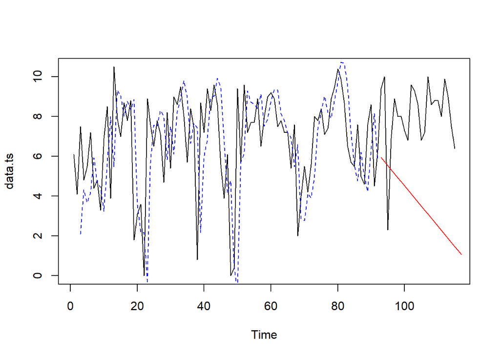

```r
#Visually evaluate the prediction
plot(data.ts)
lines(des.2$fitted[,1], lty=2, col="blue")
lines(ramalandes1$mean, col="red")
```

Untuk mendapatkan nilai parameter optimum dari DES, argumen `alpha` dan `beta` dapat dibuat `NULL`.

Selanjutnya akan dilakukan perhitungan akurasi pada data latih maupun data uji dengan ukuran akurasi SSE, MSE dan MAPE.

#### Akurasi Data Latih

```r
#Akurasi Data Training
ssedes.train1<-des.1$SSE
msedes.train1<-ssedes.train1/length(train.ts)
sisaandes1<-ramalandes1$residuals
head(sisaandes1)
```

```
## Time Series:
## Start = 1
## End = 6
## Frequency = 1
## [1]      NA      NA 5.40000 3.40400 5.07104 7.20183
```

```r
mapedes.train1 <- sum(abs(sisaandes1[3:length(train.ts)]/train.ts[3:length(train.ts)])
                      *100)/length(train.ts)

akurasides.1 <- matrix(c(ssedes.train1,msedes.train1,mapedes.train1))
row.names(akurasides.1)<- c("SSE", "MSE", "MAPE")
colnames(akurasides.1) <- c("Akurasi lamda=0.2 dan gamma=0.2")
akurasides.1
```

```
##      Akurasi lamda=0.2 dan gamma=0.2
## SSE                        944.34256
## MSE                         10.26459
## MAPE                             Inf
```

```r
ssedes.train2<-des.2$SSE
msedes.train2<-ssedes.train2/length(train.ts)
sisaandes2<-ramalandes2$residuals
head(sisaandes2)
```

```
## Time Series:
## Start = 1
## End = 6
## Frequency = 1
## [1]       NA       NA 5.400000 0.488000 1.835360 3.043939
```

```r
mapedes.train2 <- sum(abs(sisaandes2[3:length(train.ts)]/train.ts[3:length(train.ts)])
                      *100)/length(train.ts)

akurasides.2 <- matrix(c(ssedes.train2,msedes.train2,mapedes.train2))
row.names(akurasides.2)<- c("SSE", "MSE", "MAPE")
colnames(akurasides.2) <- c("Akurasi lamda=0.6 dan gamma=0.3")
akurasides.2
```

```
##      Akurasi lamda=0.6 dan gamma=0.3
## SSE                       711.698403
## MSE                         7.735852
## MAPE                             Inf
```

#### Akurasi Data Uji

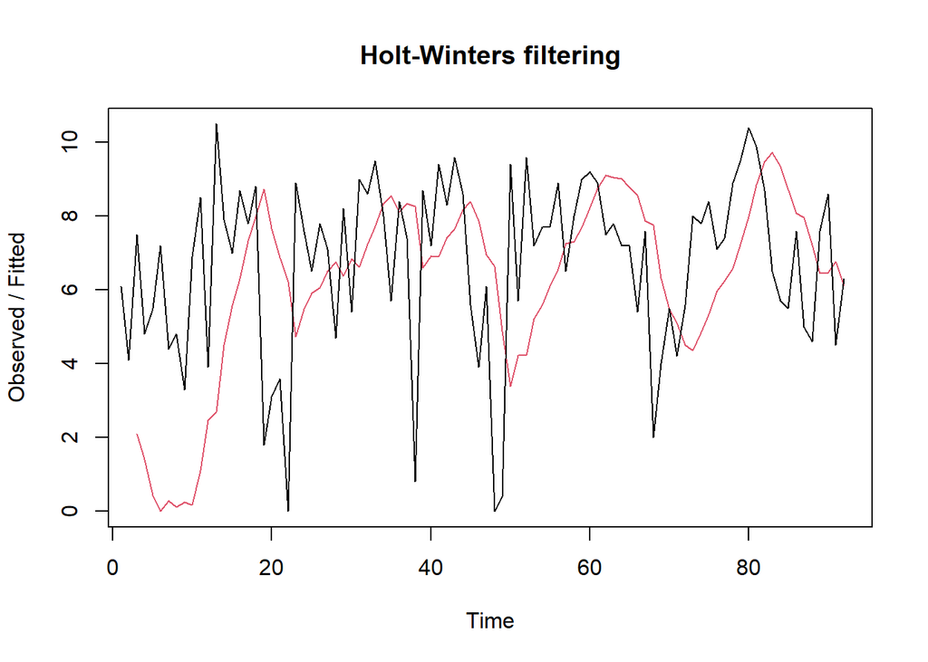

```r
#Lamda=0.2 dan gamma=0.2
des.1<- HoltWinters(train.ts, gamma = FALSE, beta = 0.2, alpha = 0.2)
plot(des.1)
```

```r
#ramalan
ramalandes1<- forecast(des.1, h=23)
ramalandes1
```

```
##     Point Forecast       Lo 80     Hi 80       Lo 95    Hi 95
##  93       5.944369   1.8196987 10.069040  -0.3637699 12.25251
##  94       5.741005   1.4992071  9.982803  -0.7462650 12.22828
##  95       5.537641   1.1414310  9.933851  -1.1857819 12.26106
##  96       5.334277   0.7442024  9.924351  -1.6856362 12.35419
##  97       5.130913   0.3066349  9.955190  -2.2471834 12.50901
##  98       4.927548  -0.1710514 10.026148  -2.8700871 12.72518
##  99       4.724184  -0.6877856 10.136154  -3.5527095 13.00108
## 100       4.520820  -1.2419215 10.283562  -4.2925327 13.33417
## 101       4.317456  -1.8314855 10.466398  -5.0865385 13.72145
## 102       4.114092  -2.4543728 10.682557  -5.9315080 14.15969
## 103       3.910728  -3.1084869 10.929943  -6.8242348 14.64569
## 104       3.707364  -3.7918271 11.206554  -7.7616589 15.17639
## 105       3.504000  -4.5025371 11.510536  -8.7409416 15.74894
## 106       3.300635  -5.2389266 11.840197  -9.7594977 16.36077
## 107       3.097271  -5.9994740 12.194017 -10.8150001 17.00954
## 108       2.893907  -6.7828193 12.570634 -11.9053688 17.69318
## 109       2.690543  -7.5877516 12.968838 -13.0287521 18.40984
## 110       2.487179  -8.4131943 13.387552 -14.1835033 19.15786
## 111       2.283815  -9.2581894 13.825819 -15.3681573 19.93579
## 112       2.080451 -10.1218833 14.282785 -16.5814087 20.74231
## 113       1.877086 -11.0035136 14.757687 -17.8220914 21.57626
## 114       1.673722 -11.9023970 15.249842 -19.0891605 22.43661
## 115       1.470358 -12.8179192 15.758636 -20.3816764 23.32239
```

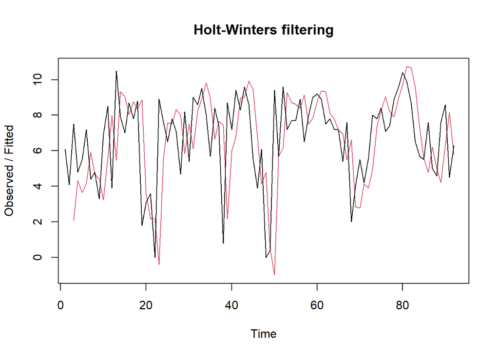

```r
#Lamda=0.6 dan gamma=0.3
des.2<- HoltWinters(train.ts, gamma = FALSE, beta = 0.3, alpha = 0.6)
plot(des.2)
```

```r
#ramalan
ramalandes2<- forecast(des.2, h=23)
ramalandes2
```

```
##     Point Forecast        Lo 80     Hi 80      Lo 95    Hi 95
##  93       6.001509   2.38068728  9.622331   0.463940 11.53908
##  94       5.911177   1.31915248 10.503201  -1.111718 12.93407
##  95       5.820845   0.06157496 11.580115  -2.987198 14.62889
##  96       5.730513  -1.35520556 12.816231  -5.106158 16.56718
##  97       5.640180  -2.90680024 14.187161  -7.431298 18.71166
##  98       5.549848  -4.57680815 15.676504  -9.937536 21.03723
##  99       5.459516  -6.35368952 17.272721 -12.607223 23.52625
## 100       5.369184  -8.22891887 18.967286 -15.427320 26.16569
## 101       5.278851 -10.19591607 20.753619 -18.387763 28.94547
## 102       5.188519 -12.24941311 22.626452 -21.480497 31.85754
## 103       5.098187 -14.38506494 24.581439 -24.698876 34.89525
## 104       5.007855 -16.59920072 26.614910 -28.037285 38.05299
## 105       4.917523 -18.88865852 28.723704 -31.490890 41.32593
## 106       4.827190 -21.25067170 30.905052 -35.055458 44.70984
## 107       4.736858 -23.68278808 33.156504 -38.727240 48.20096
## 108       4.646526 -26.18281100 35.475863 -42.502876 51.79593
## 109       4.556194 -28.74875504 37.861142 -46.379330 55.49172
## 110       4.465861 -31.37881218 40.310535 -50.353836 59.28556
## 111       4.375529 -34.07132527 42.822384 -54.423861 63.17492
## 112       4.285197 -36.82476697 45.395161 -58.587067 67.15746
## 113       4.194865 -39.63772276 48.027452 -62.841293 71.23102
## 114       4.104533 -42.50887699 50.717942 -67.184525 75.39359
## 115       4.014200 -45.43700133 53.465402 -71.614886 79.64329
```

```r
#Lamda dan gamma optimum
des.opt<- HoltWinters(train.ts, gamma = FALSE)
des.opt
```

```
## Holt-Winters exponential smoothing with trend and without seasonal component.
##
## Call:
## HoltWinters(x = train.ts, gamma = FALSE)
##
## Smoothing parameters:
##  alpha: 0.5661623
##  beta : 0.1225074
##  gamma: FALSE
##
## Coefficients:
##          [,1]
## a  6.05611525
## b -0.09869224
```

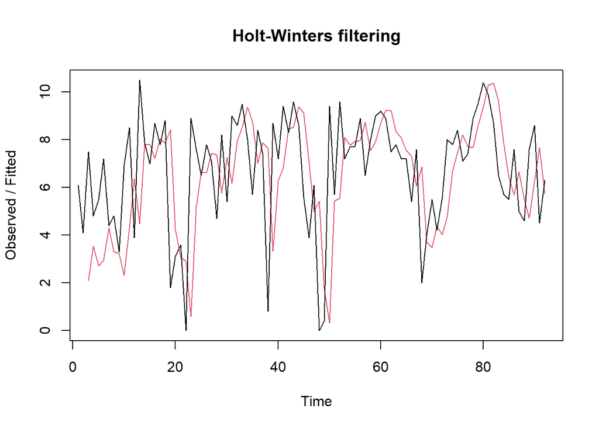

```r
plot(des.opt)
```

```r
#ramalan
ramalandesopt<- forecast(des.opt, h=23)
ramalandesopt
```

```
##     Point Forecast       Lo 80     Hi 80       Lo 95    Hi 95
##  93       5.957423   2.4690633  9.445783   0.6224372 11.29241
##  94       5.858731   1.7255214  9.991940  -0.4624674 12.17993
##  95       5.760039   0.9507253 10.569352  -1.5951713 13.11525
##  96       5.661346   0.1455549 11.177138  -2.7743286 14.09702
##  97       5.562654  -0.6890562 11.814364  -3.9985117 15.12382
##  98       5.463962  -1.5521877 12.480111  -5.2663128 16.19424
##  99       5.365270  -2.4429600 13.173499  -6.5763871 17.30693
## 100       5.266577  -3.3605455 13.893700  -7.9274685 18.46062
## 101       5.167885  -4.3041702 14.639940  -9.3183733 19.65414
## 102       5.069193  -5.2731122 15.411498 -10.7479978 20.88638
## 103       4.970501  -6.2666991 16.207700 -12.2153133 22.15631
## 104       4.871808  -7.2843037 17.027920 -13.7193607 23.46298
## 105       4.773116  -8.3253403 17.871573 -15.2592443 24.80548
## 106       4.674424  -9.3892612 18.738109 -16.8341264 26.18297
## 107       4.575732 -10.4755532 19.627016 -18.4432220 27.59469
## 108       4.477039 -11.5837341 20.537813 -20.0857940 29.03987
## 109       4.378347 -12.7133505 21.470045 -21.7611487 30.51784
## 110       4.279655 -13.8639750 22.423285 -23.4686326 32.02794
## 111       4.180963 -15.0352039 23.397129 -25.2076281 33.56955
## 112       4.082270 -16.2266553 24.391196 -26.9775511 35.14209
## 113       3.983578 -17.4379670 25.405123 -28.7778480 36.74500
## 114       3.884886 -18.6687953 26.438567 -30.6079930 38.37776
## 115       3.786194 -19.9188136 27.491201 -32.4674865 40.03987
```

```r
#Akurasi Data Testing
selisihdes1<-ramalandes1$mean-testing$`ss`
selisihdes1
```

```
## Time Series:
## Start = 93
## End = 115
## Frequency = 1
##  [1] -3.455631 -4.258995  3.237641 -1.565723 -3.769087 -3.072452 -3.275816
##  [8] -2.779180 -2.482544 -5.485908 -5.389272 -4.892636 -3.296000 -3.899365
## [15] -6.902729 -5.706093 -6.109457 -6.312821 -5.716185 -7.819549 -7.122914
## [22] -5.826278 -4.929642
```

```r
SSEtestingdes1<-sum(selisihdes1^2)
MSEtestingdes1<-SSEtestingdes1/length(testing$`ss`)
MAPEtestingdes1<-sum(abs(selisihdes1/testing$`ss`)*100)/length(testing$`ss`)

selisihdes2<-ramalandes2$mean-testing$`ss`
selisihdes2
```

```
## Time Series:
## Start = 93
## End = 115
## Frequency = 1
##  [1] -3.398491 -4.088823  3.520845 -1.169487 -3.259820 -2.450152 -2.540484
##  [8] -1.930816 -1.521149 -4.411481 -4.201813 -3.592145 -1.882477 -2.372810
## [15] -5.263142 -3.953474 -4.243806 -4.334139 -3.624471 -5.614803 -4.805135
## [22] -3.395467 -2.385800
```

```r
SSEtestingdes2<-sum(selisihdes2^2)
MSEtestingdes2<-SSEtestingdes2/length(testing$`ss`)
MAPEtestingdes2<-sum(abs(selisihdes2/testing$`ss`)*100)/length(testing$`ss`)

selisihdesopt<-ramalandesopt$mean-testing$ss[1:23]
selisihdesopt
```

```
## Time Series:
## Start = 93
## End = 115
## Frequency = 1
##  [1] -3.442577 -4.141269  3.460039 -1.238654 -3.337346 -2.536038 -2.634730
##  [8] -2.033423 -1.632115 -4.530807 -4.329499 -3.728192 -2.026884 -2.525576
## [15] -5.424268 -4.122961 -4.421653 -4.520345 -3.819037 -5.817730 -5.016422
## [22] -3.615114 -2.613806
```

```r
SSEtestingdesopt<-sum(selisihdesopt^2)
MSEtestingdesopt<-SSEtestingdesopt/length(testing$`ss`)
MAPEtestingdesopt<-sum(abs(selisihdesopt/testing$`ss`)*100)/length(testing$`ss`)

akurasitestingdes <-
  matrix(c(SSEtestingdes1,MSEtestingdes1,MAPEtestingdes1,SSEtestingdes2,MSEtestingdes2,
           MAPEtestingdes2,SSEtestingdesopt,MSEtestingdesopt,MAPEtestingdesopt),
         nrow=3,ncol=3)
row.names(akurasitestingdes)<- c("SSE", "MSE", "MAPE")
colnames(akurasitestingdes) <- c("des ske1","des ske2","des opt")
akurasitestingdes
```

```
##       des ske1  des ske2   des opt
## SSE  560.61127 295.45042 317.37891
## MSE   24.37440  12.84567  13.79908
## MAPE  59.76242  44.45584  45.97738
```

## Pemulusan Data Musiman

Pertama impor kembali data baru untuk latihan data musiman.

```r
data3 <- data
data3.ts <- ts(data3$ss)
```

Selanjutnya melakukan pembagian data dan mengubahnya menjadi data deret waktu.

```r
#membagi data menjadi training dan testing
training<-data3[1:92,3]
testing<-data3[93:115,3]
training.ts<-ts(training, frequency = 7)
testing.ts<-ts(testing, frequency = 7)
```

Metode Holt-Winter untuk peramalan data musiman menggunakan tiga persamaan pemulusan yang terdiri atas persamaan untuk level $(L_t)$, trend $(B_t)$, dan komponen seasonal / musiman $(S_t)$ dengan parameter pemulusan berupa $\alpha$, $\beta$, dan $\gamma$. Metode Holt-Winter musiman terbagi menjadi dua, yaitu metode aditif dan metode multiplikatif.

Pemulusan data musiman dengan metode Winter dilakukan menggunakan fungsi `HoltWinters()` dengan memasukkan argumen tambahan, yaitu `gamma()` dan `seasonal()` . Arguman `seasonal()` diinisialisasi menyesuaikan jenis musiman, aditif atau multiplikatif.

### Winter Aditif

Perhitungan dengan model aditif dilakukan jika plot data asli menunjukkan fluktuasi musiman yang relatif stabil (konstan).

#### Pemulusan

```r
#Pemulusan dengan winter aditif
winter1 <- HoltWinters(training.ts,alpha=0.2,beta=0.1,gamma=0.1,seasonal = "additive")
head(winter1$fitted)
```

```
## Time Series:
## Start = c(2, 1)
## End = c(2, 6)
## Frequency = 7
##              xhat    level     trend     season
## 2.000000 4.411565 5.166327 0.1217687 -0.8765306
## 2.142857 3.347361 5.365782 0.1295374 -2.1479592
## 2.285714 6.595050 5.485848 0.1285902  0.9806122
## 2.428571 6.483586 5.675428 0.1346892  0.6734694
## 2.571429 6.540458 6.213400 0.1750175  0.1520408
## 2.714286 7.948860 5.860326 0.1222083  1.9663265
```

```r
xhat1 <- winter1$fitted[,2]

winter1.opt<- HoltWinters(training.ts, alpha= NULL,  beta = NULL, gamma = NULL, seasonal = "additive")
head(winter1.opt)
```

[output not shown]

[output cut: 67 more lines]

```
## 0.3337278
##
## $beta
## beta
##    0
##
## $gamma
##     gamma
## 0.1783079
##
## $coefficients
##           a           b          s1          s2          s3          s4
##  7.02858407  0.12176871 -0.40248270 -0.21078046  0.05090266 -0.38393004
##          s5          s6          s7
## -0.31431750 -1.24842706 -0.51258237
```

```r
head(winter1.opt$fitted)
```

```
## Time Series:
## Start = c(2, 1)
## End = c(2, 6)
## Frequency = 7
##              xhat    level     trend     season
## 2.000000 4.411565 5.166327 0.1217687 -0.8765306
## 2.142857 3.391536 5.417727 0.1217687 -2.1479592
## 2.285714 6.611328 5.508947 0.1217687  0.9806122
## 2.428571 6.522292 5.727054 0.1217687  0.6734694
## 2.571429 6.782648 6.508839 0.1217687  0.1520408
## 2.714286 7.756683 5.668588 0.1217687  1.9663265
```

```r
xhat1.opt <- winter1.opt$fitted[,2]
```

#### Peramalan

```r
#Forecast
forecast1 <- predict(winter1, n.ahead = 25)
forecast1.opt <- predict(winter1.opt, n.ahead = 25)
```

#### Plot Deret Waktu

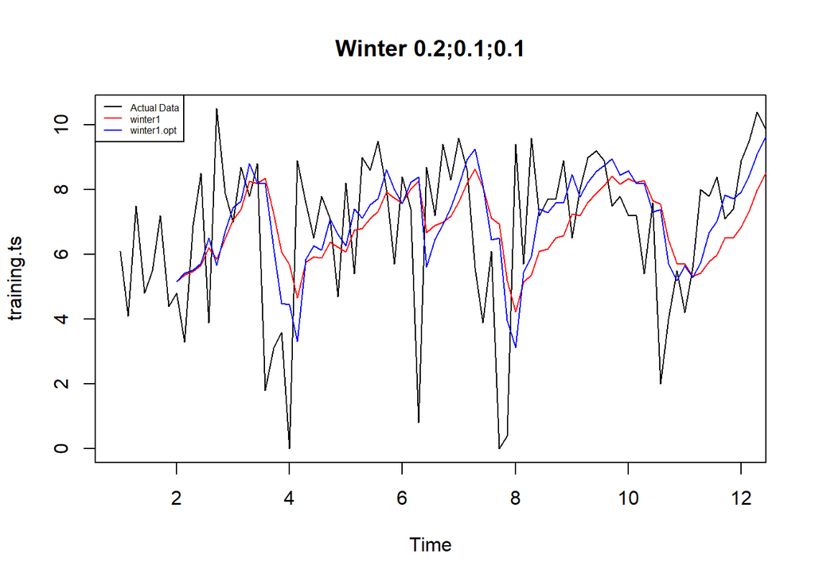

```r
#Plot time series
plot(training.ts,main="Winter 0.2;0.1;0.1",type="l",col="black",
     xlim=c(1,12),pch=12)
lines(xhat1,type="l",col="red")
lines(xhat1.opt,type="l",col="blue")
lines(forecast1,type="l",col="red")
lines(forecast1.opt,type="l",col="blue")
legend("topleft",c("Actual Data",expression(paste(winter1)),
                   expression(paste(winter1.opt))),cex=0.5,
       col=c("black","red","blue"),lty=1)
```

#### Akurasi Data Latih

```r
#Akurasi data training
SSE1<-winter1$SSE
MSE1<-winter1$SSE/length(training.ts)
RMSE1<-sqrt(MSE1)
akurasi1 <- matrix(c(SSE1,MSE1,RMSE1))
row.names(akurasi1)<- c("SSE", "MSE", "RMSE")
colnames(akurasi1) <- c("Akurasi")
akurasi1
```

```
##         Akurasi
## SSE  671.953847
## MSE    7.303846
## RMSE   2.702563
```

```r
SSE1.opt<-winter1.opt$SSE
MSE1.opt<-winter1.opt$SSE/length(training.ts)
RMSE1.opt<-sqrt(MSE1.opt)
akurasi1.opt <- matrix(c(SSE1.opt,MSE1.opt,RMSE1.opt))
row.names(akurasi1.opt)<- c("SSE1.opt", "MSE1.opt", "RMSE1.opt")
colnames(akurasi1.opt) <- c("Akurasi")
akurasi1.opt
```

```
##              Akurasi
## SSE1.opt  614.727001
## MSE1.opt    6.681815
## RMSE1.opt   2.584921
```

```r
akurasi1.train = data.frame(Model_Winter = c("Winter 1","Winter1 optimal"),
                            Nilai_SSE=c(SSE1,SSE1.opt),
                            Nilai_MSE=c(MSE1,MSE1.opt),Nilai_RMSE=c(RMSE1,RMSE1.opt))
akurasi1.train
```

```
##      Model_Winter Nilai_SSE Nilai_MSE Nilai_RMSE
## 1        Winter 1  671.9538  7.303846   2.702563
## 2 Winter1 optimal  614.7270  6.681815   2.584921
```

#### Akurasi Data Uji

```r
#Akurasi Data Testing
accuracy(forecast1.opt,testing[1:25])
```

```
##                  ME     RMSE      MAE       MPE    MAPE
## Test set 0.02228342 1.789531 1.331072 -8.580694 23.1002
```